# INN Hotels Project

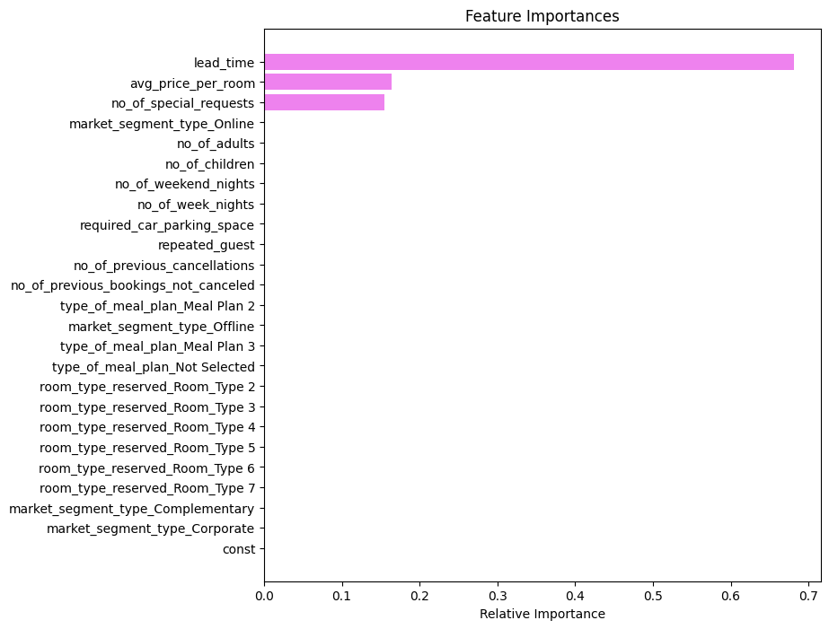

```python
feature_names = list(X_train.columns)
importances = bestEst.feature_importances_
indices = np.argsort(importances)

plt.figure(figsize=(8, 8))
plt.title("Feature Importances")
plt.barh(range(len(indices)), importances[indices], color="violet", align="center")
plt.yticks(range(len(indices)), [feature_names[i] for i in indices])
plt.xlabel("Relative Importance")
plt.show()
```

This graph plots the relative importance of each feature for the decision tree.

```python
DTClassifier = DecisionTreeClassifier(random_state = 1)
ccp_path = DTClassifier.cost_complexity_pruning_path(X_train, Y_train)
alphas = ccp_path.ccp_alphas
impurities = ccp_path.impurities
pd.DataFrame(ccp_path)
```

|  | ccp_alphas | impurities |
| --- | --- | --- |
| 0 | 0.000000 | 0.003818 |
| 1 | 0.000015 | 0.003832 |
| 2 | 0.000050 | 0.004084 |
| 3 | 0.000063 | 0.004336 |
| 4 | 0.000092 | 0.004428 |
| ... | ... | ... |
| 262 | 0.006638 | 0.291758 |
| 263 | 0.009734 | 0.301492 |
| 264 | 0.018766 | 0.320258 |
| 265 | 0.024141 | 0.368540 |
| 266 | 0.078089 | 0.446628 |

267 rows × 2 columns

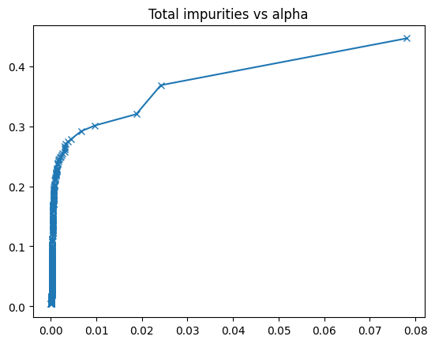

```python
plt.plot(alphas, impurities, marker = 'x')
plt.title("Total impurities vs alpha")
plt.show()
```

```python
classifierList = []
for ccp_alpha in alphas:
  clf = DecisionTreeClassifier(random_state = 1, ccp_alpha = ccp_alpha)
  clf.fit(X_train, Y_train)
  classifierList.append(clf)
```

```python
classifierList = classifierList[:-1]
alphas = alphas[:-1]
node_counts = [i.tree_.node_count for i in classifierList]
depth_counts = [i.tree_.max_depth for i in classifierList]
```

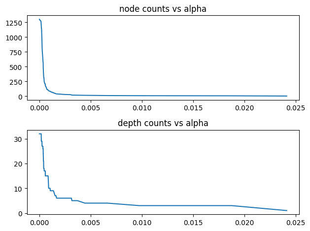

```python
fig, ax = plt.subplots(2)
ax[0].plot(alphas, node_counts)
ax[0].set_title("node counts vs alpha")
ax[1].plot(alphas, depth_counts)
ax[1].set_title("depth counts vs alpha")

fig.tight_layout()
```

```python
recall_train = []
for i in classifierList:
  prediction = i.predict(X_train)
  recall_value = recall_score(Y_train, prediction)
  recall_train.append(recall_value)

recall_test = []
for i in classifierList:
  prediction = i.predict(X_test)
  recall_value = recall_score(Y_test, prediction)
  recall_test.append(recall_value)
```

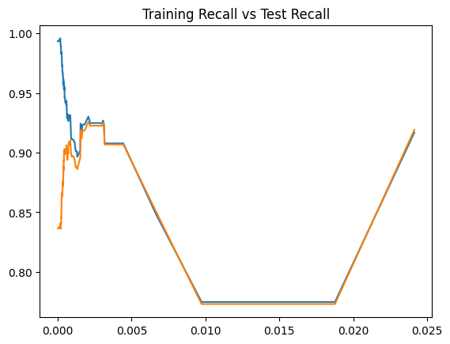

```python
plt.plot(alphas, recall_train)
plt.plot(alphas, recall_test)
plt.title("Training Recall vs Test Recall")
plt.show()
```

```python
idx_of_best_test_recall = np.argmax(recall_test)

bestModel = classifierList[idx_of_best_test_recall]
print(bestModel)
```

```
DecisionTreeClassifier(ccp_alpha=0.002074055561167208, random_state=1)
```

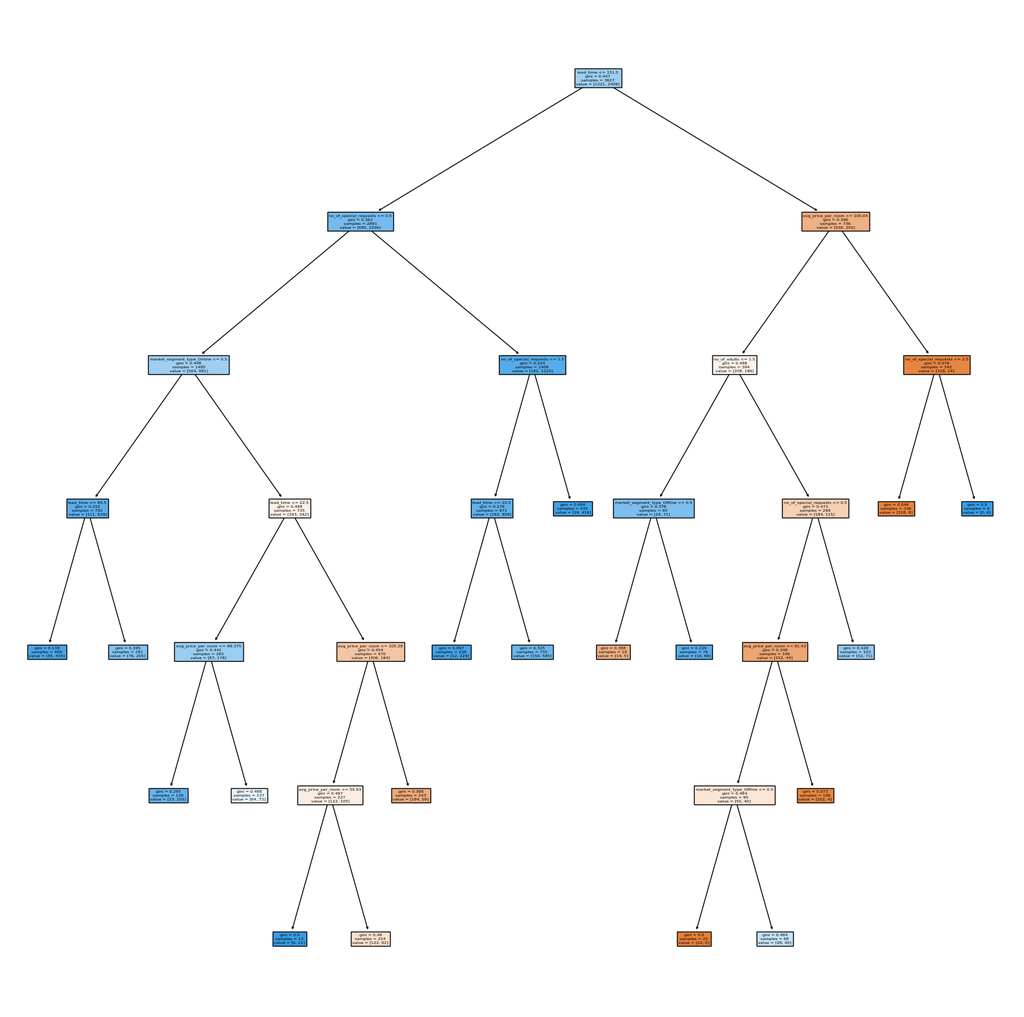

```python
plt.figure(figsize = (20,20))
tree_plot = tree.plot_tree(bestModel, feature_names = X_train.columns, filled = True)


plt.show()
```

```python
features_names = list(X_train.columns)
print(tree.export_text(bestModel, feature_names= feature_names, show_weights=True))
```

```
|--- lead_time <= 151.50
|   |--- no_of_special_requests <= 0.50
|   |   |--- market_segment_type_Online <= 0.50
|   |   |   |--- lead_time <= 65.50
|   |   |   |   |--- weights: [35.00, 434.00] class: 1
|   |   |   |--- lead_time >  65.50
|   |   |   |   |--- weights: [76.00, 205.00] class: 1
|   |   |--- market_segment_type_Online >  0.50
|   |   |   |--- lead_time <= 22.50
|   |   |   |   |--- avg_price_per_room <= 99.38
|   |   |   |   |   |--- weights: [23.00, 105.00] class: 1
|   |   |   |   |--- avg_price_per_room >  99.38
|   |   |   |   |   |--- weights: [64.00, 73.00] class: 1
|   |   |   |--- lead_time >  22.50
|   |   |   |   |--- avg_price_per_room <= 105.28
|   |   |   |   |   |--- avg_price_per_room <= 55.93
|   |   |   |   |   |   |--- weights: [0.00, 13.00] class: 1
|   |   |   |   |   |--- avg_price_per_room >  55.93
|   |   |   |   |   |   |--- weights: [122.00, 92.00] class: 0
|   |   |   |   |--- avg_price_per_room >  105.28
|   |   |   |   |   |--- weights: [184.00, 59.00] class: 0
|   |--- no_of_special_requests >  0.50
|   |   |--- no_of_special_requests <= 1.50
|   |   |   |--- lead_time <= 10.50
|   |   |   |   |--- weights: [12.00, 224.00] class: 1
|   |   |   |--- lead_time >  10.50
|   |   |   |   |--- weights: [150.00, 585.00] class: 1
|   |   |--- no_of_special_requests >  1.50
|   |   |   |--- weights: [19.00, 416.00] class: 1
|--- lead_time >  151.50
|   |--- avg_price_per_room <= 100.04
|   |   |--- no_of_adults <= 1.50
|   |   |   |--- market_segment_type_Offline <= 0.50
|   |   |   |   |--- weights: [14.00, 5.00] class: 0
|   |   |   |--- market_segment_type_Offline >  0.50
|   |   |   |   |--- weights: [10.00, 66.00] class: 1
|   |   |--- no_of_adults >  1.50
|   |   |   |--- no_of_special_requests <= 0.50
|   |   |   |   |--- avg_price_per_room <= 81.43
|   |   |   |   |   |--- market_segment_type_Offline <= 0.50
|   |   |   |   |   |   |--- weights: [22.00, 0.00] class: 0
|   |   |   |   |   |--- market_segment_type_Offline >  0.50
|   |   |   |   |   |   |--- weights: [28.00, 40.00] class: 1
|   |   |   |   |--- avg_price_per_room >  81.43
|   |   |   |   |   |--- weights: [102.00, 4.00] class: 0
|   |   |   |--- no_of_special_requests >  0.50
|   |   |   |   |--- weights: [32.00, 71.00] class: 1
|   |--- avg_price_per_room >  100.04
|   |   |--- no_of_special_requests <= 2.50
|   |   |   |--- weights: [328.00, 8.00] class: 0
|   |   |--- no_of_special_requests >  2.50
|   |   |   |--- weights: [0.00, 6.00] class: 1
```

Above is the post pruning method that creates an alpha value for each subtree that is pruned from the original tree. An alpha value indicates the error of the subtree compared to the error of the original tree. What tends to happen is that as the alpha increases, nodes decrease, and the recall for the test data increases and reaches a peak. We want to create a model that has the alpha value that gives us the peak recall for the test data, although it might not be the highest recall for the training data.

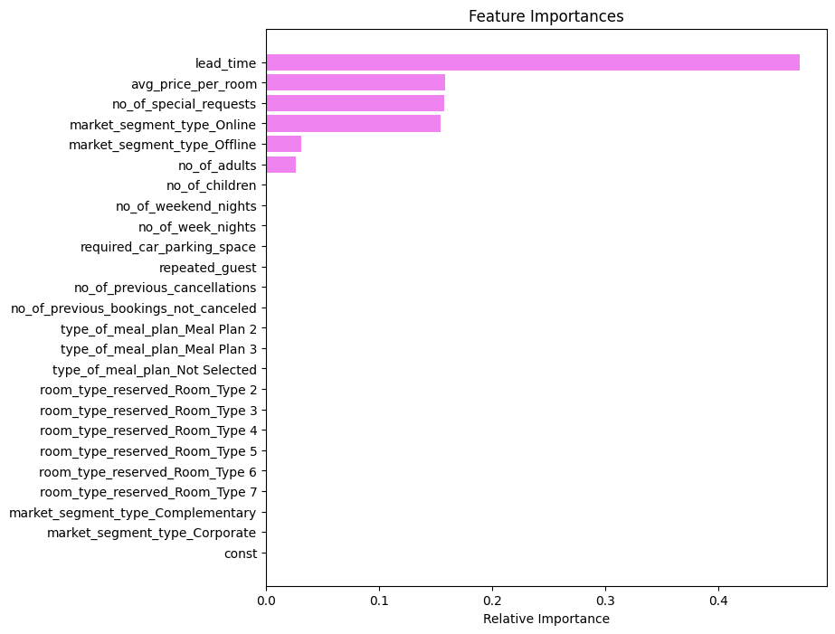

```python
feature_names = list(X_train.columns)
importances = bestModel.feature_importances_
indices = np.argsort(importances)

plt.figure(figsize=(8, 8))
plt.title("Feature Importances")
plt.barh(range(len(indices)), importances[indices], color="violet", align="center")
plt.yticks(range(len(indices)), [feature_names[i] for i in indices])
plt.xlabel("Relative Importance")
plt.show()
```